# R Notebook

```r
library(ggplot2)
```

> We load the data and give a quick look at the header

```r
movies <- get(load("movies.RData"))
```

```r
head(movies)
```

|  | title | title_type | genre | runtime | mpaa_rating | studio | thtr_rel_year | thtr_rel_month | thtr_rel_day | dvd_rel_year | dvd_rel_month | dvd_rel_day | imdb_rating | imdb_num_votes | critics_rating | critics_score | audience_rating | audience_score | best_pic_nom | best_pic_win | best_actor_win | best_actress_win | best_dir_win | top200_box | director | actor1 | actor2 | actor3 | actor4 | … |
| --- | --- | --- | --- | --- | --- | --- | --- | --- | --- | --- | --- | --- | --- | --- | --- | --- | --- | --- | --- | --- | --- | --- | --- | --- | --- | --- | --- | --- | --- | --- |
| 1 | Filly Brown | Feature Film | Drama | 80 | R | Indomina Media Inc. | 2013 | 4 | 19 | 2013 | 7 | 30 | 5.5 | 899 | Rotten | 45 | Upright | 73 | no | no | no | no | no | no | Michael D. Olmos | Gina Rodriguez | Jenni Rivera | Lou Diamond Phillips | Emilio Rivera | … |
| 2 | The Dish | Feature Film | Drama | 101 | PG-13 | Warner Bros. Pictures | 2001 | 3 | 14 | 2001 | 8 | 28 | 7.3 | 12285 | Certified Fresh | 96 | Upright | 81 | no | no | no | no | no | no | Rob Sitch | Sam Neill | Kevin Harrington | Patrick Warburton | Tom Long | … |
| 3 | Waiting for Guffman | Feature Film | Comedy | 84 | R | Sony Pictures Classics | 1996 | 8 | 21 | 2001 | 8 | 21 | 7.6 | 22381 | Certified Fresh | 91 | Upright | 91 | no | no | no | no | no | no | Christopher Guest | Christopher Guest | Catherine O'Hara | Parker Posey | Eugene Levy | … |
| 4 | The Age of Innocence | Feature Film | Drama | 139 | PG | Columbia Pictures | 1993 | 10 | 1 | 2001 | 11 | 6 | 7.2 | 35096 | Certified Fresh | 80 | Upright | 76 | no | no | yes | no | yes | no | Martin Scorsese | Daniel Day-Lewis | Michelle Pfeiffer | Winona Ryder | Richard E. Grant | … |
| 5 | Malevolence | Feature Film | Horror | 90 | R | Anchor Bay Entertainment | 2004 | 9 | 10 | 2005 | 4 | 19 | 5.1 | 2386 | Rotten | 33 | Spilled | 27 | no | no | no | no | no | no | Stevan Mena | Samantha Dark | R. Brandon Johnson | Brandon Johnson | Heather Magee | … |
| 6 | Old Partner | Documentary | Documentary | 78 | Unrated | Shcalo Media Group | 2009 | 1 | 15 | 2010 | 4 | 20 | 7.8 | 333 | Fresh | 91 | Upright | 86 | no | no | no | no | no | no | Chung-ryoul Lee | Choi Won-kyun | Lee Sam-soon | Moo | NA | … |

> Looking for NAN values

```r
movies[!complete.cases(movies['runtime']),]
```

|  | title | title_type | genre | runtime | mpaa_rating | studio | thtr_rel_year | thtr_rel_month | thtr_rel_day | dvd_rel_year | dvd_rel_month | dvd_rel_day | imdb_rating | imdb_num_votes | critics_rating | critics_score | audience_rating | audience_score | best_pic_nom | best_pic_win | best_actor_win | best_actress_win | best_dir_win | top200_box | director | actor1 | actor2 | actor3 | actor4 | … |
| --- | --- | --- | --- | --- | --- | --- | --- | --- | --- | --- | --- | --- | --- | --- | --- | --- | --- | --- | --- | --- | --- | --- | --- | --- | --- | --- | --- | --- | --- | --- |
| 334 | The End of America | Documentary | Documentary | NA | Unrated | Indipix | 2008 | 10 | 1 | 2009 | 1 | 20 | 7.5 | 739 | Fresh | 80 | Upright | 72 | no | no | no | no | no | no | Anne Sundberg | Naomi Wolf | NA | NA | NA | … |

> We can find the runtime of the movie “The End of America” in Google, which is 74 minutes.

```r
movies$runtime[movies$title == "The End of America"] <- 74
```

```r
movies[!complete.cases(movies['director']),]
```

|  | title | title_type | genre | runtime | mpaa_rating | studio | thtr_rel_year | thtr_rel_month | thtr_rel_day | dvd_rel_year | dvd_rel_month | dvd_rel_day | imdb_rating | imdb_num_votes | critics_rating | critics_score | audience_rating | audience_score | best_pic_nom | best_pic_win | best_actor_win | best_actress_win | best_dir_win | top200_box | director | actor1 | actor2 | actor3 | actor4 | … |
| --- | --- | --- | --- | --- | --- | --- | --- | --- | --- | --- | --- | --- | --- | --- | --- | --- | --- | --- | --- | --- | --- | --- | --- | --- | --- | --- | --- | --- | --- | --- |
| 172 | Lorenzo's Oil | Feature Film | Drama | 129 | PG-13 | MCA Universal Home Video | 1992 | 12 | 30 | 2004 | 4 | 6 | 7.2 | 15913 | Fresh | 94 | Upright | 79 | no | no | no | yes | no | no | NA | Nick Nolte | Susan Sarandon | Peter Ustinov | Kathleen Wilhoite | … |
| 460 | The Ninth Gate | Feature Film | Mystery & Suspense | 133 | R | Artisan Entertainment | 1999 | 12 | 24 | 2000 | 7 | 18 | 6.7 | 134031 | Rotten | 41 | Spilled | 57 | no | no | no | no | no | no | NA | Johnny Depp | Frank Langella | Lena Olin | Emmanuelle Seigner | … |

> We can find the missing directors as well.

```r
movies$director[movies$title == "Lorenzo's Oil"] <- "George Miller"
movies$director[movies$title == "The Ninth Gate"] <- "Roman Polanski"
```

```r
movies[!complete.cases(movies["studio"]),]
```

|  | title | title_type | genre | runtime | mpaa_rating | studio | thtr_rel_year | thtr_rel_month | thtr_rel_day | dvd_rel_year | dvd_rel_month | dvd_rel_day | imdb_rating | imdb_num_votes | critics_rating | critics_score | audience_rating | audience_score | best_pic_nom | best_pic_win | best_actor_win | best_actress_win | best_dir_win | top200_box | director | actor1 | actor2 | actor3 | actor4 | … |
| --- | --- | --- | --- | --- | --- | --- | --- | --- | --- | --- | --- | --- | --- | --- | --- | --- | --- | --- | --- | --- | --- | --- | --- | --- | --- | --- | --- | --- | --- | --- |
| 94 | Dirty Sanchez: The Movie | Documentary | Comedy | 94 | R | NA | 2007 | 9 | 11 | 2007 | 9 | 4 | 6.2 | 3851 | Rotten | 40 | Upright | 75 | no | no | no | no | no | no | Jim Hickey | Lee Dainton | Dan Joyce | Michael Pancho Locke | Matt Pritchard | … |
| 207 | Caveman | Feature Film | Action & Adventure | 91 | PG | NA | 1981 | 4 | 17 | 2002 | 6 | 4 | 5.7 | 5564 | Rotten | 24 | Spilled | 55 | no | no | no | no | no | no | Carl Gottlieb | Ringo Starr | Dennis Quaid | Shelley Long | Jack Gilford | … |
| 223 | Attack of the 50 Foot Woman | TV Movie | Other | 90 | R | NA | 1993 | 12 | 11 | 2002 | 4 | 2 | 3.8 | 2289 | Rotten | 22 | Spilled | 21 | no | no | no | no | no | no | Christopher Guest | Daryl Hannah | Daniel Baldwin | Xander Berkeley | NA | … |
| 282 | Oliver & Company | Feature Film | Animation | 74 | G | NA | 1988 | 11 | 18 | 2002 | 5 | 14 | 6.7 | 30886 | Rotten | 43 | Upright | 63 | no | no | no | no | no | no | George Scribner | Joey Lawrence | Billy Joel | Cheech Marin | Bette Midler | … |
| 308 | The Man Who Sued God | Feature Film | Drama | 97 | R | NA | 2001 | 10 | 25 | 2007 | 3 | 13 | 6.5 | 4251 | Fresh | 71 | Spilled | 59 | no | no | no | no | no | no | Mark Joffe | Billy Connolly | Judy Davis | Colin Friels | Bille Brown | … |
| 402 | Inserts | Feature Film | Drama | 117 | NC-17 | NA | 1975 | 1 | 1 | 2005 | 8 | 23 | 6.4 | 1043 | Fresh | 80 | Spilled | 56 | no | no | yes | no | no | no | John Byrum | Richard Dreyfuss | Jessica Harper | Stephen Davies | Veronica Cartwright | … |
| 467 | Inbred | Feature Film | Art House & International | 90 | R | NA | 2011 | 8 | 29 | 2013 | 9 | 23 | 5.3 | 3461 | Rotten | 13 | Spilled | 29 | no | no | no | no | no | no | Alex Chandon | James Burrows | James Doherty | Jo Hartley | Seamus O'Neill | … |
| 536 | Death Line (Raw Meat) | Feature Film | Horror | 87 | R | NA | 1972 | 1 | 1 | 2003 | 8 | 26 | 6.0 | 2433 | Fresh | 86 | Spilled | 44 | no | no | no | no | no | no | Gary Sherman | Hugh Armstrong | James Cossins | Sharon Gurney | David Ladd | … |

> It seems that there are 8 films without a studio associated

```r
movies[!complete.cases(movies["dvd_rel_year"]),]
```

|  | title | title_type | genre | runtime | mpaa_rating | studio | thtr_rel_year | thtr_rel_month | thtr_rel_day | dvd_rel_year | dvd_rel_month | dvd_rel_day | imdb_rating | imdb_num_votes | critics_rating | critics_score | audience_rating | audience_score | best_pic_nom | best_pic_win | best_actor_win | best_actress_win | best_dir_win | top200_box | director | actor1 | actor2 | actor3 | actor4 | … |
| --- | --- | --- | --- | --- | --- | --- | --- | --- | --- | --- | --- | --- | --- | --- | --- | --- | --- | --- | --- | --- | --- | --- | --- | --- | --- | --- | --- | --- | --- | --- |
| 100 | Charlie: The Life and Art of Charles Chaplin | Documentary | Documentary | 132 | Unrated | Warner Bros. | 2004 | 2 | 13 | NA | NA | NA | 8.0 | 1147 | Fresh | 95 | Upright | 90 | no | no | no | no | no | no | Richard Schickel | Woody Allen | Johnny Depp | Sydney Pollack | Milos Forman | … |
| 184 | Streets of Gold | Feature Film | Drama | 95 | R | Live Home Video | 1986 | 11 | 14 | NA | NA | NA | 6.0 | 486 | Rotten | 31 | Spilled | 44 | no | no | no | no | no | no | Joe Roth | Klaus Maria Brandauer | Adrian Pasdar | Richard Pasdar | Wesley Snipes | … |
| 261 | The Squeeze | Feature Film | Action & Adventure | 101 | PG-13 | HBO Video | 1987 | 7 | 10 | NA | NA | NA | 4.5 | 703 | Rotten | 17 | Spilled | 33 | no | no | no | no | no | no | Roger Young | Michael Keaton | Rae Dawn Chong | Meat Loaf | John Davidson | … |
| 345 | Electric Dreams | Feature Film | Drama | 95 | PG | MGM | 1984 | 7 | 20 | NA | NA | NA | 6.5 | 5149 | Rotten | 47 | Upright | 72 | no | no | no | no | no | no | Steve Barron | Lenny Von Dohlen | Virginia Madsen | Maxwell Caulfield | Bud Cort | … |
| 375 | Porky's Revenge | Feature Film | Art House & International | 92 | R | 20th Century Fox | 1985 | 3 | 22 | NA | NA | NA | 4.6 | 5863 | Rotten | 27 | Spilled | 33 | no | no | no | no | no | no | James Komack | Dan Monahan | Wyatt Knight | Mark Herrier | Tony Ganios | … |
| 377 | Teen Wolf Too | Feature Film | Science Fiction & Fantasy | 95 | PG | Paramount Home Video | 1987 | 11 | 20 | NA | NA | NA | 3.1 | 8319 | Rotten | 7 | Spilled | 17 | no | no | no | no | no | no | Christopher Leitch | Jason Bateman | Kim Darby | John Astin | Estee Chandler | … |
| 437 | The Last Remake of Beau Geste | Feature Film | Action & Adventure | 85 | PG | MCA Universal Home Video | 1977 | 7 | 15 | NA | NA | NA | 6.0 | 1680 | Rotten | 33 | Upright | 65 | no | no | no | no | no | no | Marty Feldman | Marty Feldman | Ann-Margret | Michael York | Peter Ustinov | … |
| 451 | Let It Be | Documentary | Documentary | 81 | G | United Artists | 1970 | 5 | 20 | NA | NA | NA | 7.9 | 3887 | Fresh | 82 | Upright | 87 | no | no | no | no | no | no | Michael Lindsay-Hogg | Beatles The | Paul McCartney | Ringo Starr | George Harrison | … |

> And 8 films withouth a DVD

```r
movies[!complete.cases(movies["actor5"]),]
```

|  | title | title_type | genre | runtime | mpaa_rating | studio | thtr_rel_year | thtr_rel_month | thtr_rel_day | dvd_rel_year | dvd_rel_month | dvd_rel_day | imdb_rating | imdb_num_votes | critics_rating | critics_score | audience_rating | audience_score | best_pic_nom | best_pic_win | best_actor_win | best_actress_win | best_dir_win | top200_box | director | actor1 | actor2 | actor3 | actor4 | … |
| --- | --- | --- | --- | --- | --- | --- | --- | --- | --- | --- | --- | --- | --- | --- | --- | --- | --- | --- | --- | --- | --- | --- | --- | --- | --- | --- | --- | --- | --- | --- |
| 6 | Old Partner | Documentary | Documentary | 78 | Unrated | Shcalo Media Group | 2009 | 1 | 15 | 2010 | 4 | 20 | 7.8 | 333 | Fresh | 91 | Upright | 86 | no | no | no | no | no | no | Chung-ryoul Lee | Choi Won-kyun | Lee Sam-soon | Moo | NA | … |
| 25 | The Yes Men Fix the World | Documentary | Documentary | 87 | Unrated | Cinetic Media | 2009 | 1 | 18 | 2010 | 4 | 1 | 7.6 | 4541 | Certified Fresh | 79 | Upright | 77 | no | no | no | no | no | no | Andy Bichlbaum | Andy Bichlbaum | Reggie Waits | Mike Bonanno | NA | … |
| 131 | Africa: The Serengeti | Documentary | Documentary | 39 | Unrated | Houston Museum of Natural Scie | 1994 | 4 | 8 | 1998 | 11 | 18 | 7.3 | 535 | Fresh | 100 | Upright | 74 | no | no | no | no | no | no | George Casey | James Earl Jones | NA | NA | NA | … |
| 175 | Kicking It | Documentary | Documentary | 98 | Unrated | Liberation Entertainment | 2008 | 6 | 13 | 2008 | 9 | 9 | 7.4 | 325 | Rotten | 53 | Upright | 71 | no | no | no | no | no | no | Jeff Werner | Colin Farrell | Brandon Francis | NA | NA | … |
| 198 | Gaza Strip | Documentary | Documentary | 74 | Unrated | Arab Film Distribution | 2002 | 1 | 1 | 2003 | 5 | 6 | 7.3 | 285 | Fresh | 78 | Upright | 89 | no | no | no | no | no | no | James Longley | NA | NA | NA | NA | … |
| 223 | Attack of the 50 Foot Woman | TV Movie | Other | 90 | R | NA | 1993 | 12 | 11 | 2002 | 4 | 2 | 3.8 | 2289 | Rotten | 22 | Spilled | 21 | no | no | no | no | no | no | Christopher Guest | Daryl Hannah | Daniel Baldwin | Xander Berkeley | NA | … |
| 236 | Closet Land | Feature Film | Mystery & Suspense | 89 | R | Media Home Entertainment | 1991 | 3 | 6 | 1991 | 9 | 12 | 7.2 | 2098 | Rotten | 44 | Upright | 86 | no | no | no | no | no | no | Radha Bharadwaj | Madeleine Stowe | Alan Rickman | NA | NA | … |
| 334 | The End of America | Documentary | Documentary | 74 | Unrated | Indipix | 2008 | 10 | 1 | 2009 | 1 | 20 | 7.5 | 739 | Fresh | 80 | Upright | 72 | no | no | no | no | no | no | Anne Sundberg | Naomi Wolf | NA | NA | NA | … |
| 386 | Jonestown: The Life and Death of Peoples Temple | Documentary | Documentary | 86 | Unrated | 7th art | 2006 | 10 | 20 | 2007 | 4 | 10 | 7.9 | 3649 | Certified Fresh | 94 | Upright | 88 | no | no | no | no | no | no | Stanley Nelson | NA | NA | NA | NA | … |
| 399 | The Last Lions | Documentary | Documentary | 88 | PG | National Geographic Entertainment | 2011 | 2 | 18 | 2012 | 1 | 3 | 8.4 | 3128 | Fresh | 87 | Upright | 89 | no | no | yes | no | no | no | Dereck Joubert | Jeremy Irons | NA | NA | NA | … |

[output cut: 5 more lines]

> And 15 films without one or more of the five main actors.

> Lets remove columns and add them up!

```r
movies$thtr_rel_date <- as.Date(paste0(movies$thtr_rel_year, "-", movies$thtr_rel_month, "-", movies$thtr_rel_day))
movies$dvd_rel_date <- as.Date(paste0(movies$dvd_rel_year, "-", movies$dvd_rel_month, "-", movies$dvd_rel_day))

movies$dvd_rel_day <- NULL
movies$dvd_rel_month <- NULL
movies$dvd_rel_year <- NULL

movies$thtr_rel_day <- NULL
movies$thtr_rel_month <- NULL
movies$thtr_rel_year <- NULL

movies$imdb_url <- NULL
movies$rt_url <- NULL
```

> Cleaner!

```r
head(movies)
```

|  | title | title_type | genre | runtime | mpaa_rating | studio | imdb_rating | imdb_num_votes | critics_rating | critics_score | audience_rating | audience_score | best_pic_nom | best_pic_win | best_actor_win | best_actress_win | best_dir_win | top200_box | director | actor1 | actor2 | actor3 | actor4 | actor5 | thtr_rel_date | dvd_rel_date |
| --- | --- | --- | --- | --- | --- | --- | --- | --- | --- | --- | --- | --- | --- | --- | --- | --- | --- | --- | --- | --- | --- | --- | --- | --- | --- | --- |
| 1 | Filly Brown | Feature Film | Drama | 80 | R | Indomina Media Inc. | 5.5 | 899 | Rotten | 45 | Upright | 73 | no | no | no | no | no | no | Michael D. Olmos | Gina Rodriguez | Jenni Rivera | Lou Diamond Phillips | Emilio Rivera | Joseph Julian Soria | 2013-04-19 | 2013-07-30 |
| 2 | The Dish | Feature Film | Drama | 101 | PG-13 | Warner Bros. Pictures | 7.3 | 12285 | Certified Fresh | 96 | Upright | 81 | no | no | no | no | no | no | Rob Sitch | Sam Neill | Kevin Harrington | Patrick Warburton | Tom Long | Genevieve Mooy | 2001-03-14 | 2001-08-28 |
| 3 | Waiting for Guffman | Feature Film | Comedy | 84 | R | Sony Pictures Classics | 7.6 | 22381 | Certified Fresh | 91 | Upright | 91 | no | no | no | no | no | no | Christopher Guest | Christopher Guest | Catherine O'Hara | Parker Posey | Eugene Levy | Bob Balaban | 1996-08-21 | 2001-08-21 |
| 4 | The Age of Innocence | Feature Film | Drama | 139 | PG | Columbia Pictures | 7.2 | 35096 | Certified Fresh | 80 | Upright | 76 | no | no | yes | no | yes | no | Martin Scorsese | Daniel Day-Lewis | Michelle Pfeiffer | Winona Ryder | Richard E. Grant | Alec McCowen | 1993-10-01 | 2001-11-06 |
| 5 | Malevolence | Feature Film | Horror | 90 | R | Anchor Bay Entertainment | 5.1 | 2386 | Rotten | 33 | Spilled | 27 | no | no | no | no | no | no | Stevan Mena | Samantha Dark | R. Brandon Johnson | Brandon Johnson | Heather Magee | Richard Glover | 2004-09-10 | 2005-04-19 |
| 6 | Old Partner | Documentary | Documentary | 78 | Unrated | Shcalo Media Group | 7.8 | 333 | Fresh | 91 | Upright | 86 | no | no | no | no | no | no | Chung-ryoul Lee | Choi Won-kyun | Lee Sam-soon | Moo | NA | NA | 2009-01-15 | 2010-04-20 |

> Now, some very basic visualization!

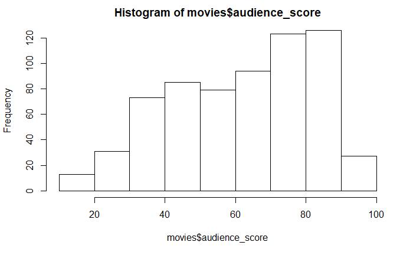

```r
hist(movies$audience_score)
```

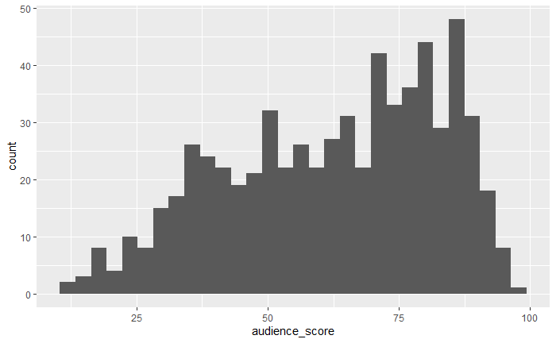

```r
ggplot(movies, aes(x=audience_score)) + geom_histogram()
```

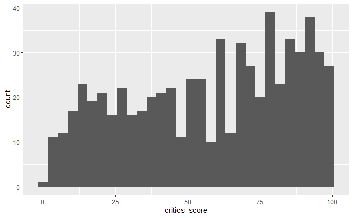

```r
ggplot(movies, aes(x=critics_score)) + geom_histogram()
```

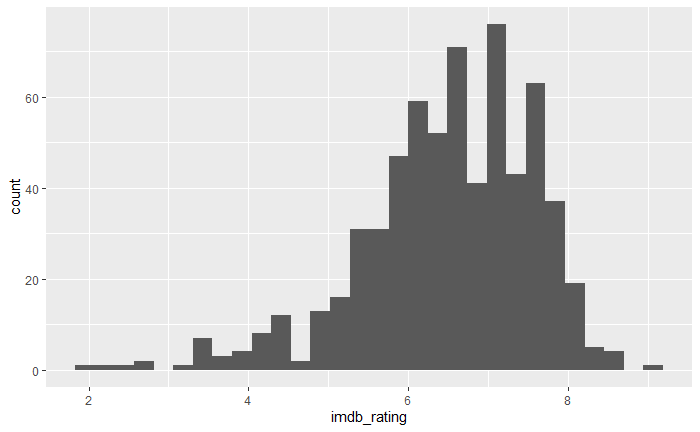

```r
ggplot(movies, aes(x=imdb_rating)) + geom_histogram()
```

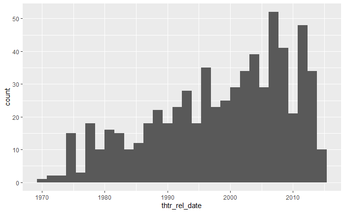

```r
ggplot(movies, aes(x=thtr_rel_date)) + geom_histogram()
```

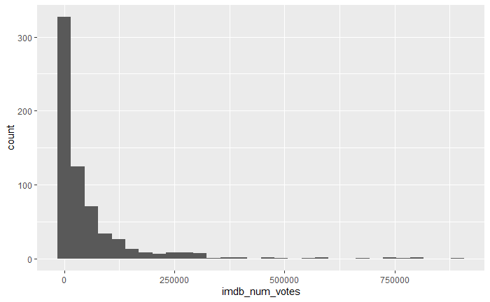

```r
ggplot(movies, aes(x=imdb_num_votes)) + geom_histogram()
```

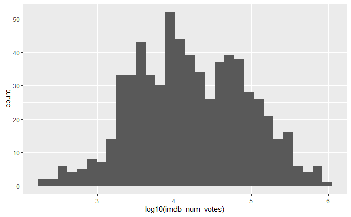

```r
ggplot(movies, aes(x=log10(imdb_num_votes))) + geom_histogram()
```

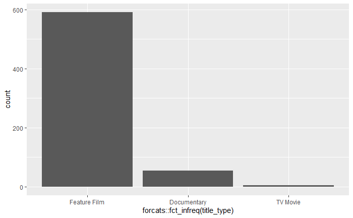

```r
ggplot(aes(x=forcats::fct_infreq(title_type)), data=movies) + geom_bar()
```

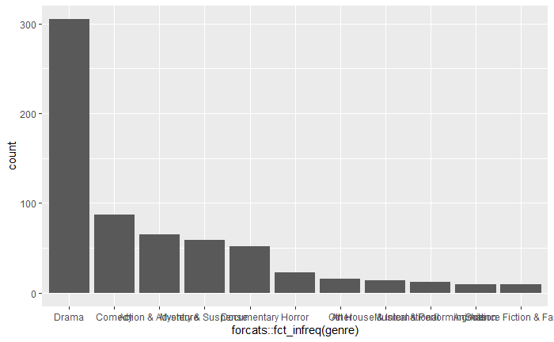

```r
ggplot(aes(x=forcats::fct_infreq(genre)), data=movies) + geom_bar()
```

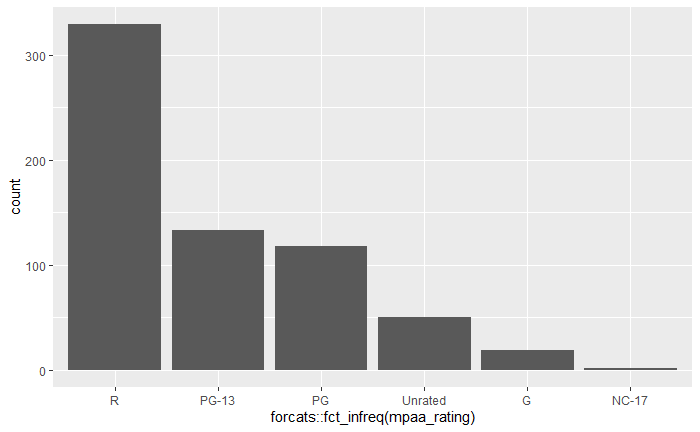

```r
ggplot(aes(x=forcats::fct_infreq(mpaa_rating)), data=movies) + geom_bar()
```

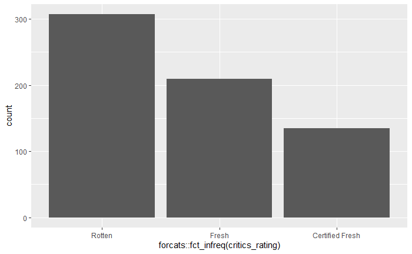

```r
ggplot(aes(x=forcats::fct_infreq(critics_rating)), data=movies) + geom_bar()
```

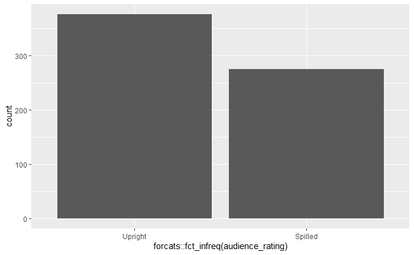

```r
ggplot(aes(x=forcats::fct_infreq(audience_rating)), data=movies) + geom_bar()
```

> Some continuous plotting:

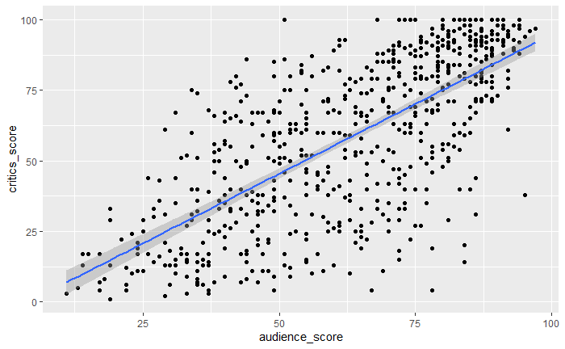

```r
ggplot(data=movies, aes(x=audience_score, y=critics_score)) + geom_point() + geom_smooth(method='lm')
```

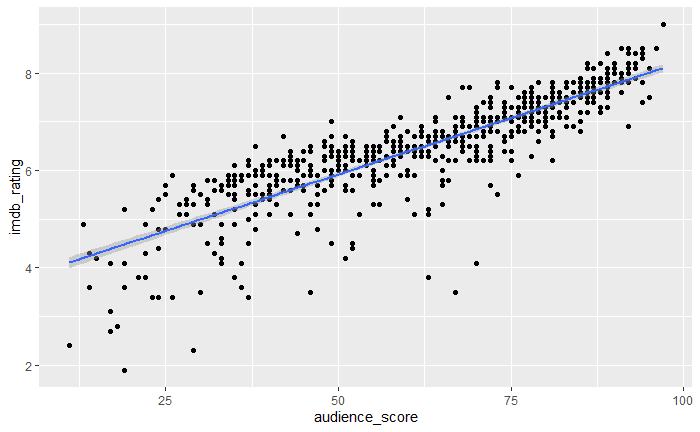

```r
ggplot(data=movies, aes(x=audience_score, y=imdb_rating)) + geom_point() + geom_smooth(method='lm')
```

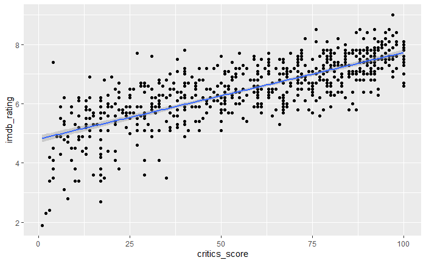

```r
ggplot(data=movies, aes(x=critics_score, y=imdb_rating)) + geom_point() + geom_smooth(method='lm')
```

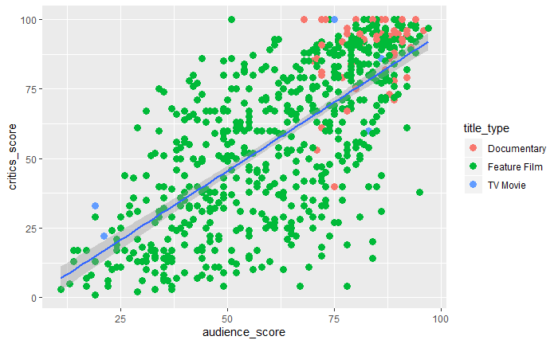

```r
ggplot(data=movies, aes(x=audience_score, y=critics_score)) + geom_point(aes(col=title_type), size=3) + geom_smooth(method='lm')
```

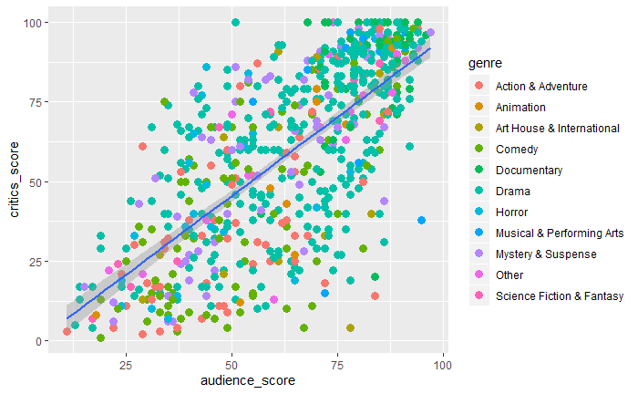

```r
ggplot(data=movies, aes(x=audience_score, y=critics_score)) + geom_point(aes(col=genre), size=3) + geom_smooth(method='lm')
```

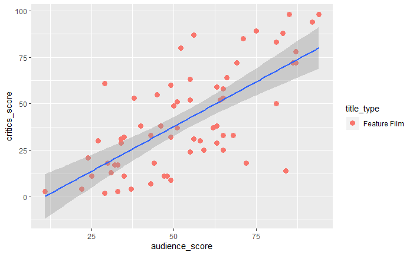

```r
ggplot(data=subset(movies, genre == "Action & Adventure"), aes(x=audience_score, y=critics_score)) + geom_point(aes(col=title_type), size=3) + geom_smooth(method='lm')
```

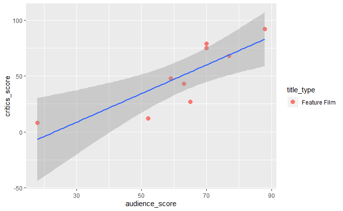

```r
ggplot(data=subset(movies, genre == "Animation"), aes(x=audience_score, y=critics_score)) + geom_point(aes(col=title_type), size=3) + geom_smooth(method='lm')
```

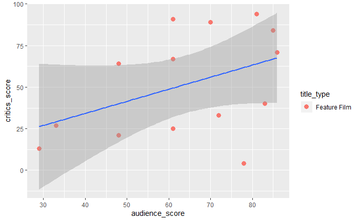

```r
ggplot(data=subset(movies, genre == "Art House & International"), aes(x=audience_score, y=critics_score)) + geom_point(aes(col=title_type), size=3) + geom_smooth(method='lm')
```

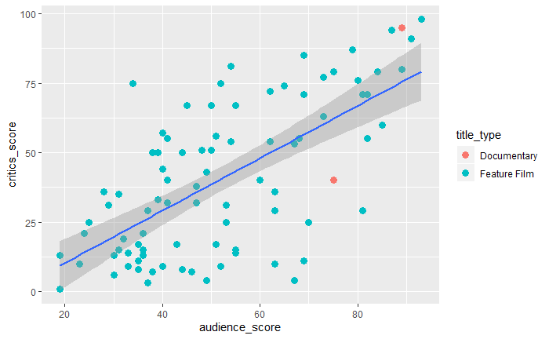

```r
ggplot(data=subset(movies, genre == "Comedy"), aes(x=audience_score, y=critics_score)) + geom_point(aes(col=title_type), size=3) + geom_smooth(method='lm')
```

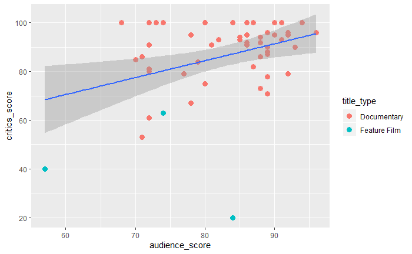

```r
ggplot(data=subset(movies, genre == "Documentary"), aes(x=audience_score, y=critics_score)) + geom_point(aes(col=title_type), size=3) + geom_smooth(method='lm')
```

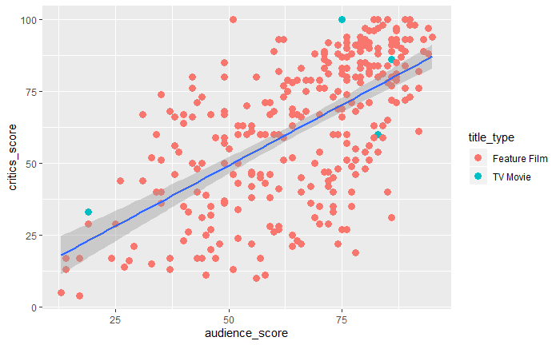

```r
ggplot(data=subset(movies, genre == "Drama"), aes(x=audience_score, y=critics_score)) + geom_point(aes(col=title_type), size=3) + geom_smooth(method='lm')
```

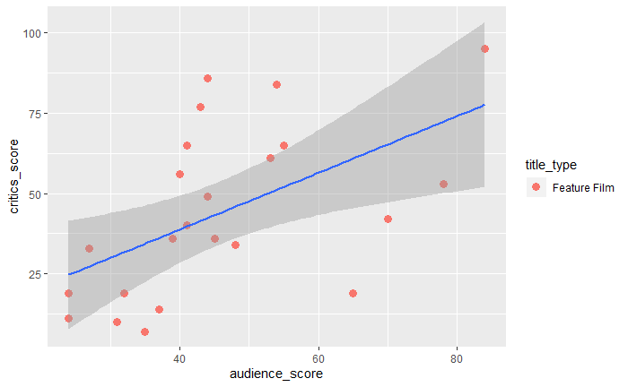

```r
ggplot(data=subset(movies, genre == "Horror"), aes(x=audience_score, y=critics_score)) + geom_point(aes(col=title_type), size=3) + geom_smooth(method='lm')
```

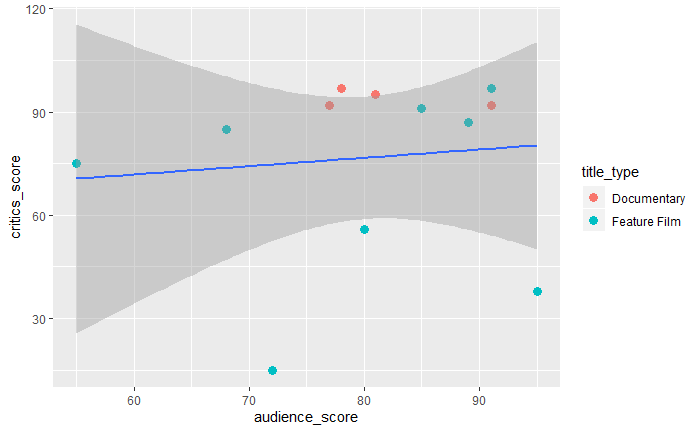

```r
ggplot(data=subset(movies, genre == "Musical & Performing Arts"), aes(x=audience_score, y=critics_score)) + geom_point(aes(col=title_type), size=3) + geom_smooth(method='lm')
```

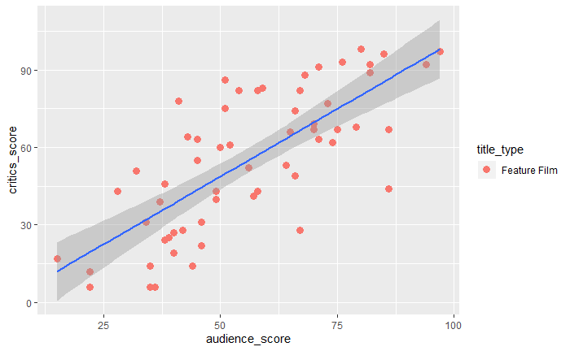

```r
ggplot(data=subset(movies, genre == "Mystery & Suspense"), aes(x=audience_score, y=critics_score)) + geom_point(aes(col=title_type), size=3) + geom_smooth(method='lm')
```

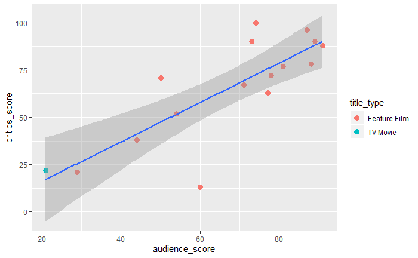

```r
ggplot(data=subset(movies, genre == "Other"), aes(x=audience_score, y=critics_score)) + geom_point(aes(col=title_type), size=3) + geom_smooth(method='lm')
```

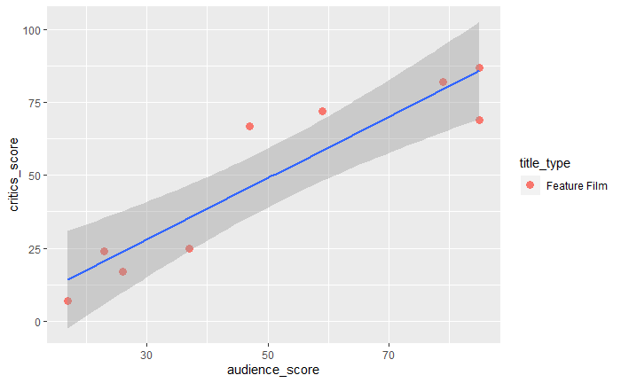

```r
ggplot(data=subset(movies, genre == "Science Fiction & Fantasy"), aes(x=audience_score, y=critics_score)) + geom_point(aes(col=title_type), size=3) + geom_smooth(method='lm')
```

```r
nrow(movies[movies$best_pic_win == "yes" | movies$best_actor_win == "yes" | movies$best_actress_win == "yes" | movies$best_dir_win == "yes",])
```

```
[1] 171
```

```r
nrow(movies)
```

```
[1] 651
```

> Are oscar-awarded films more liked?

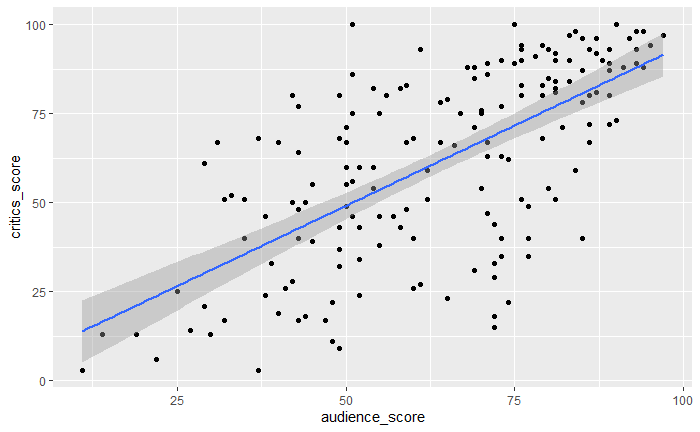

```r
ggplot(data=movies[movies$best_pic_win == "yes" | movies$best_actor_win == "yes" | movies$best_actress_win == "yes" | movies$best_dir_win == "yes",],
       aes(x=audience_score, y=critics_score)) + geom_point() + geom_smooth(method='lm')
```

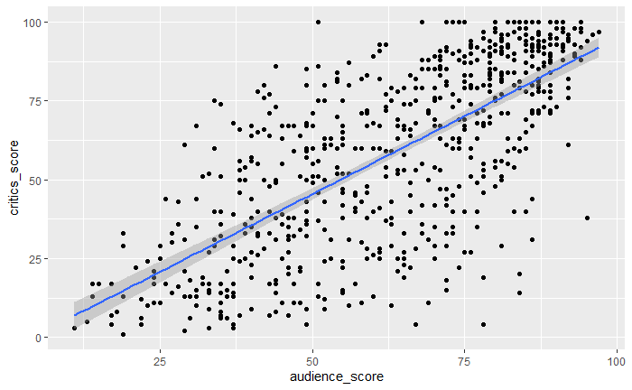

```r
ggplot(data=movies, aes(x=audience_score, y=critics_score)) + geom_point() + geom_smooth(method='lm')
```

> It seems that not really

> 1-Is there a relationship between the type/genre and score?

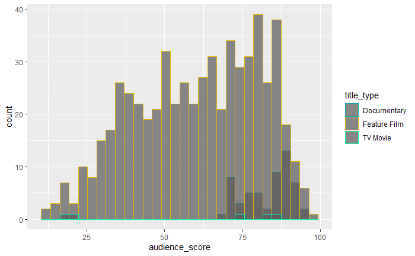

```r
ggplot(data=movies, aes(x=audience_score)) + geom_histogram(bins=30, aes(color = title_type), position = "identity", alpha = 0.7) + scale_color_manual(values = c("#00AFBB", "#E7B800", "#0AFBB0")) + scale_fill_manual(values = c("#00AFBB", "#E7B800", "#0AFBB0"))
```

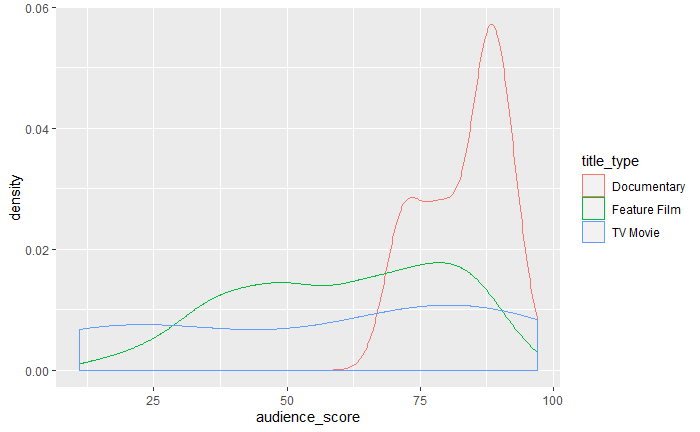

```r
ggplot(data=movies, aes(x=audience_score)) + geom_density(aes(color = title_type), kernel = "gaussian")
```

> It seems that Documentaries are very highly rated by the audience. Feature Films are more evenly distributed, and so are TV Movies (though there are not many samples)

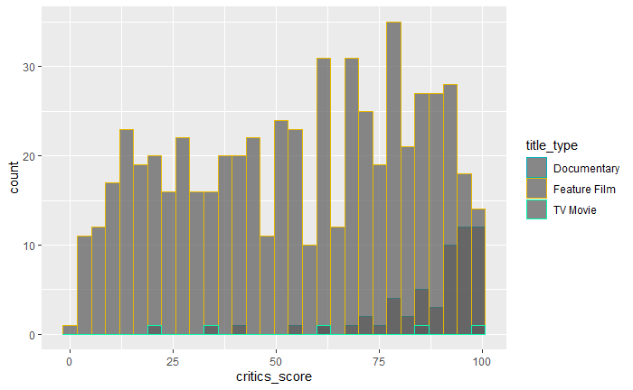

```r
ggplot(data=movies, aes(x=critics_score)) + geom_histogram(bins=30, aes(color = title_type), position = "identity", alpha = 0.7) + scale_color_manual(values = c("#00AFBB", "#E7B800", "#0AFBB0")) + scale_fill_manual(values = c("#00AFBB", "#E7B800", "#0AFBB0"))
```

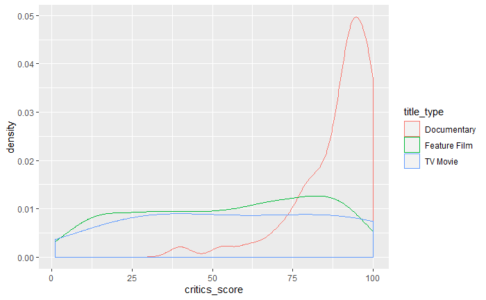

```r
ggplot(data=movies, aes(x=critics_score)) + geom_density(aes(color = title_type), kernel = "gaussian")
```

> This phenomenom is even more accentuated when we take into account the rating of critics.

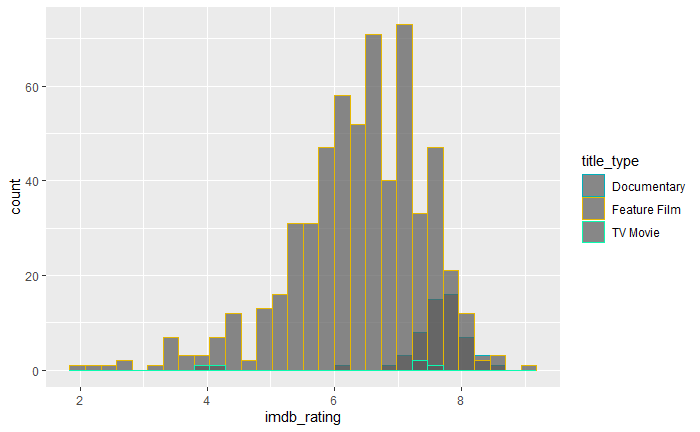

```r
ggplot(data=movies, aes(x=imdb_rating)) + geom_histogram(bins=30, aes(color = title_type), position = "identity", alpha = 0.7) + scale_color_manual(values = c("#00AFBB", "#E7B800", "#0AFBB0")) + scale_fill_manual(values = c("#00AFBB", "#E7B800", "#0AFBB0"))
```

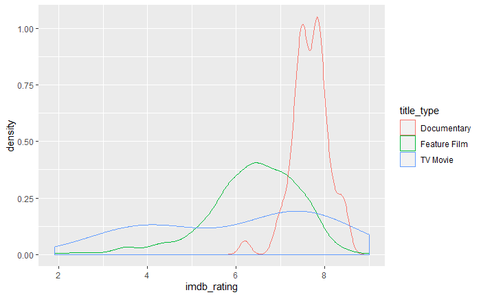

```r
ggplot(data=movies, aes(x=imdb_rating)) + geom_density(aes(color = title_type), kernel = "gaussian")
```

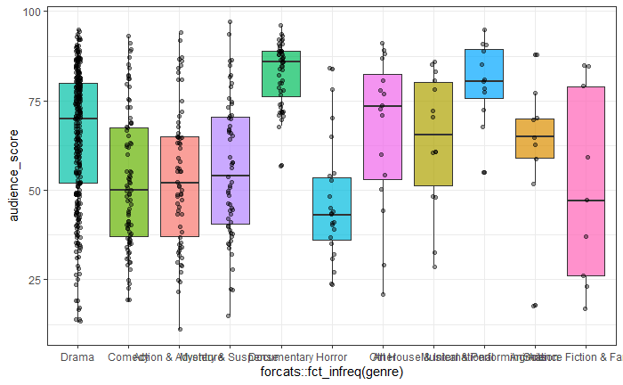

```r
ggplot(data=movies, aes(x = forcats::fct_infreq(genre), y = audience_score, group = genre, fill = genre)) + geom_boxplot(alpha = .7) + geom_jitter(width = .05, alpha = .4) + guides(fill = "none") + theme_bw()
```

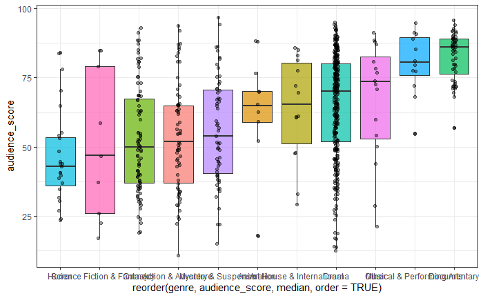

```r
ggplot(data=movies, aes(x = reorder(genre, audience_score, median, order=TRUE), y = audience_score, group = genre, fill = genre)) + geom_boxplot(alpha = .7) + geom_jitter(width = .05, alpha = .4) + guides(fill = "none") + theme_bw()
```

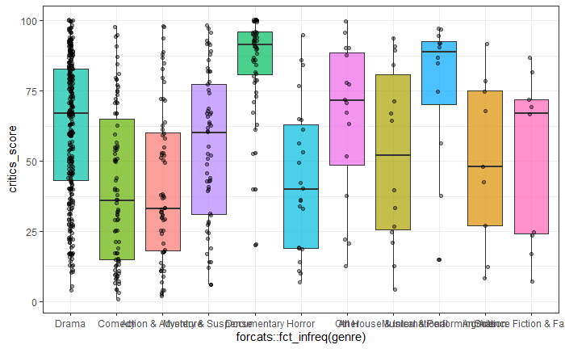

```r
ggplot(data=movies, aes(x = forcats::fct_infreq(genre), y = critics_score, group = genre, fill = genre)) + geom_boxplot(alpha = .7) + geom_jitter(width = .05, alpha = .4) + guides(fill = "none") + theme_bw()
```

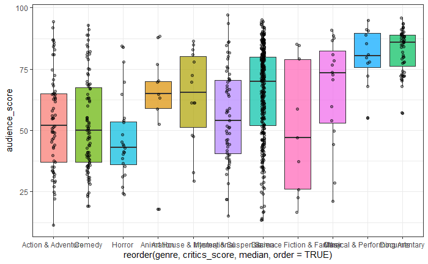

```r
ggplot(data=movies, aes(x = reorder(genre, critics_score, median, order=TRUE), y = audience_score, group = genre, fill = genre)) + geom_boxplot(alpha = .7) + geom_jitter(width = .05, alpha = .4) + guides(fill = "none") + theme_bw()
```

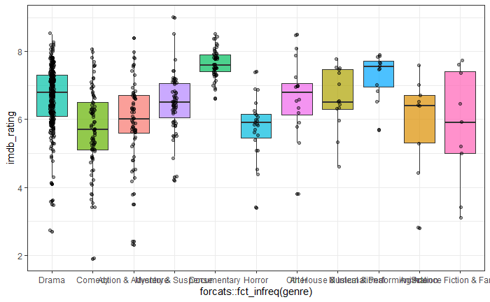

```r
ggplot(data=movies, aes(x = forcats::fct_infreq(genre), y = imdb_rating, group = genre, fill = genre)) + geom_boxplot(alpha = .7) + geom_jitter(width = .05, alpha = .4) + guides(fill = "none") + theme_bw()
```

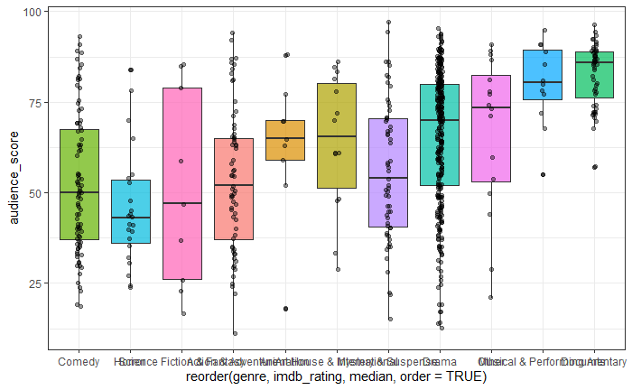

```r
ggplot(data=movies, aes(x = reorder(genre, imdb_rating, median, order=TRUE), y = audience_score, group = genre, fill = genre)) + geom_boxplot(alpha = .7) + geom_jitter(width = .05, alpha = .4) + guides(fill = "none") + theme_bw()
```

> Apart from Documentaries, and Music films, would you say there are genres more liked than others?

> 3-Comparison best picture/oscar wins and score/oscar wins. Are oscar-awarded films more liked?

> 4-What are the trends over the years? -Preferred month for releases? number of films by month (over the years? does it affect the score?) -Does the genre change over the years? -Do older films tend to have higher score/number of votes? if this is true, it could be because only good old films get remembered